[figure not shown]

## Project Overview

This project focuses on predicting robbery rates within U.S. municipalities as an indicator of economic distress. By understanding and anticipating financial strain in communities, the study aims to guide resource allocation and interventions to support economic stability.

## Background

- **Municipal Economic Health:** Economic growth in towns and cities is essential for the well-being of residents. Expanding infrastructure, information technology, and e-commerce have created opportunities for municipalities to flourish.
- **Case Study - Detroit:** Detroit’s economic decline, following the deindustrialization and relocation of major automobile manufacturers, exemplifies how economic downturns can lead to increased violent crime and population outflow.

## Problem Statement

Robbery rates can reflect economic strain in municipalities. By predicting robbery trends, we can identify communities facing financial distress and address root causes through targeted policies and resources.

## Hypothesis

Higher robbery rates are associated with economic hardship in communities. Predicting these rates can enable proactive interventions, which may help reduce economic-driven crime and improve residents' quality of life.

## Objectives

- **Predict Robbery Rates:** Track trends and identify factors contributing to elevated robbery rates in municipalities.
- **Guide Policy and Interventions:** Use robbery rate predictions to inform policymakers, enabling targeted support for economically distressed areas.

## Key Takeaway

Robbery rates serve as a key metric for identifying economically distressed communities. Accurate predictions can support data-driven resource allocation, helping to foster resilient communities and improve residents’ quality of life.

# Introduction

```python
# Import Packages
import numpy as np
import pandas as pd
import matplotlib.pyplot as plt
import seaborn as sns
import statsmodels.api as sm
from statsmodels.stats.outliers_influence import variance_inflation_factor
from sklearn.preprocessing import MinMaxScaler
from sklearn.metrics import mean_squared_error, r2_score
from sklearn.ensemble import RandomForestRegressor
from sklearn.model_selection import train_test_split

pd.set_option('display.max_columns', None)
pd.set_option('display.max_rows', None)
```

```python
df = pd.read_csv('datasets/crimedata2.csv')
```

```python
df.shape
```

```
(2215, 147)
```

```python
df.head(3)
```

|  | Ecommunityname | state | countyCode | communityCode | fold | population | householdsize | racepctblack | racePctWhite | racePctAsian | racePctHisp | agePct12t21 | agePct12t29 | agePct16t24 | agePct65up | numbUrban | pctUrban | medIncome | pctWWage | pctWFarmSelf | pctWInvInc | pctWSocSec | pctWPubAsst | pctWRetire | medFamInc | perCapInc | whitePerCap | blackPerCap | indianPerCap | … |
| --- | --- | --- | --- | --- | --- | --- | --- | --- | --- | --- | --- | --- | --- | --- | --- | --- | --- | --- | --- | --- | --- | --- | --- | --- | --- | --- | --- | --- | --- | --- |
| 0 | BerkeleyHeightstownship | NJ | 39 | 5320 | 1 | 11980 | 3.10 | 1.37 | 91.78 | 6.50 | 1.88 | 12.47 | 21.44 | 10.93 | 11.33 | 11980 | 100.0 | 75122 | 89.24 | 1.55 | 70.20 | 23.62 | 1.03 | 18.39 | 79584 | 29711 | 30233 | 13600 | 5725 | … |
| 1 | Marpletownship | PA | 45 | 47616 | 1 | 23123 | 2.82 | 0.80 | 95.57 | 3.44 | 0.85 | 11.01 | 21.30 | 10.48 | 17.18 | 23123 | 100.0 | 47917 | 78.99 | 1.11 | 64.11 | 35.50 | 2.75 | 22.85 | 55323 | 20148 | 20191 | 18137 | 0 | … |
| 2 | Tigardcity | OR | ? | ? | 1 | 29344 | 2.43 | 0.74 | 94.33 | 3.43 | 2.35 | 11.36 | 25.88 | 11.01 | 10.28 | 29344 | 100.0 | 35669 | 82.00 | 1.15 | 55.73 | 22.25 | 2.94 | 14.56 | 42112 | 16946 | 17103 | 16644 | 21606 | … |

[figure not shown]

# Functions

```python
import matplotlib.pyplot as plt
import seaborn as sns

import matplotlib.pyplot as plt
import seaborn as sns

def boxplot(df, column_name,
            box_color="#EBD8D4",
            median_color="#323335",
            whisker_color="#EBD8D4",
            flier_color="#EBD8D4",
            hist_color="#ddd0ca",
            kde_color="#fef176",
            background_color="#323335"):
    """
    Plots a boxplot and a histogram with a KDE overlay for the specified column in the DataFrame with a custom color scheme.

    Parameters:
    - df: DataFrame containing the data.
    - column_name: The name of the column to plot.
    - box_color: Color of the boxplot.
    - median_color: Color of the median line.
    - whisker_color: Color of the whiskers.
    - flier_color: Color of the fliers.
    - hist_color: Color for histogram bars.
    - kde_color: Color for the KDE line.
    - background_color: Color of the plot background.
    """
    plt.figure(figsize=(10, 12), facecolor=background_color)  # Set the figure background color

    # Row 1: Boxplot
    plt.subplot(2, 1, 1)  # 2 rows, 1 column, first subplot
    plt.boxplot(df[column_name], vert=False,
                patch_artist=True,
                boxprops=dict(facecolor=box_color, color=box_color),
                medianprops=dict(color=median_color, linewidth=1.5),
                whiskerprops=dict(color=whisker_color, linewidth=2),
                capprops=dict(color=whisker_color, linewidth=2),
                flierprops=dict(marker='o', markerfacecolor=flier_color))

    plt.title(f'Boxplot of {column_name}', color=box_color)
    plt.xlabel(column_name, color=box_color)
    plt.ylabel(' ', color=box_color)

    # Set the background color and spine colors for the boxplot
    plt.gca().set_facecolor(background_color)
    plt.gca().spines['bottom'].set_color(box_color)
    plt.gca().spines['top'].set_color(background_color)
    plt.gca().spines['right'].set_color(background_color)
    plt.gca().spines['left'].set_color(box_color)

    # Set x and y tick colors
    plt.tick_params(axis='x', colors=box_color)
    plt.tick_params(axis='y', colors=box_color)

    # Row 2: Histogram with KDE
    plt.subplot(2, 1, 2)  # 2 rows, 1 column, second subplot
    sns.histplot(df[column_name], kde=True, color=hist_color, fill=True)

    # Customize KDE line color and width
    kde_lines = plt.gca().get_lines()  # Get the KDE lines
    if kde_lines:
        kde_lines[0].set_color(kde_color)
        kde_lines[0].set_linewidth(3)

    plt.title(f'Distribution of {column_name}', color=box_color)
    plt.xlabel(column_name, color=box_color)
    plt.ylabel(' ', color=box_color)

    # Set the background color for the histogram
    plt.gca().set_facecolor(background_color)
    plt.gca().spines['bottom'].set_color(box_color)
    plt.gca().spines['top'].set_color(background_color)
    plt.gca().spines['right'].set_color(background_color)
    plt.gca().spines['left'].set_color(box_color)

    # Set x and y tick colors for the histogram
    plt.tick_params(axis='x', colors=box_color)
    plt.tick_params(axis='y', colors=box_color)

    # Show the plot
    plt.tight_layout()
    plt.show()


def colToNumeric(col):
    try: return pd.to_numeric(col)
    except ValueError: return col

#Function to remove outliers based on IQR
def removeOutliersIQR(df, column):

    q1 = np.percentile(df[column], 25)
    q3 = np.percentile(df[column], 75)

    iqr = q3 - q1
    upperThreshold = q3 + (1.5 * iqr)
    lowerThreshold = q1 - (1.5 * iqr)

    df = df[(df[column] <= upperThreshold) & (df[column] >= lowerThreshold)]

    return df
```

```python
df.replace('?', np.nan, inplace=True)
```

```python
objects = df.dtypes[df.dtypes == 'object']
objects
```

```
Ecommunityname          object
state                   object
countyCode              object
communityCode           object
OtherPerCap             object
LemasSwornFT            object
LemasSwFTPerPop         object
LemasSwFTFieldOps       object
LemasSwFTFieldPerPop    object
LemasTotalReq           object
LemasTotReqPerPop       object
PolicReqPerOffic        object
PolicPerPop             object
RacialMatchCommPol      object
PctPolicWhite           object
PctPolicBlack           object
PctPolicHisp            object
PctPolicAsian           object
PctPolicMinor           object
OfficAssgnDrugUnits     object
NumKindsDrugsSeiz       object
PolicAveOTWorked        object
PolicCars               object
PolicOperBudg           object
LemasPctPolicOnPatr     object
LemasGangUnitDeploy     object
PolicBudgPerPop         object
rapes                   object
rapesPerPop             object
robberies               object
robbbPerPop             object
assaults                object
assaultPerPop           object
burglaries              object
burglPerPop             object
larcenies               object
larcPerPop              object
autoTheft               object
autoTheftPerPop         object
arsons                  object
arsonsPerPop            object
ViolentCrimesPerPop     object
nonViolPerPop           object
dtype: object
```

```python
for col in df.columns:
    if df[col].dtype == 'object': df[col] = colToNumeric(df[col])
```

```python
df.dtypes
```

```
Ecommunityname            object
state                     object
countyCode               float64
communityCode            float64
fold                       int64
population                 int64
householdsize            float64
racepctblack             float64
racePctWhite             float64
racePctAsian             float64
racePctHisp              float64
agePct12t21              float64
agePct12t29              float64
agePct16t24              float64
agePct65up               float64
numbUrban                  int64
pctUrban                 float64
medIncome                  int64
pctWWage                 float64
pctWFarmSelf             float64
pctWInvInc               float64
pctWSocSec               float64
pctWPubAsst              float64
pctWRetire               float64
medFamInc                  int64
perCapInc                  int64
whitePerCap                int64
blackPerCap                int64
indianPerCap               int64
AsianPerCap                int64
OtherPerCap              float64
HispPerCap                 int64
NumUnderPov                int64
PctPopUnderPov           float64
PctLess9thGrade          float64
PctNotHSGrad             float64
PctBSorMore              float64
PctUnemployed            float64
PctEmploy                float64
PctEmplManu              float64
```

[output cut: 93 more lines]

```
robberies                float64
robbbPerPop              float64
assaults                 float64
assaultPerPop            float64
burglaries               float64
burglPerPop              float64
larcenies                float64
larcPerPop               float64
autoTheft                float64
autoTheftPerPop          float64
arsons                   float64
arsonsPerPop             float64
ViolentCrimesPerPop      float64
nonViolPerPop            float64
dtype: object
```

```python
results = df.isna().sum()
results[results > 0]
```

```
countyCode              1221
communityCode           1224
OtherPerCap                1
LemasSwornFT            1872
LemasSwFTPerPop         1872
LemasSwFTFieldOps       1872
LemasSwFTFieldPerPop    1872
LemasTotalReq           1872
LemasTotReqPerPop       1872
PolicReqPerOffic        1872
PolicPerPop             1872
RacialMatchCommPol      1872
PctPolicWhite           1872
PctPolicBlack           1872
PctPolicHisp            1872
PctPolicAsian           1872
PctPolicMinor           1872
OfficAssgnDrugUnits     1872
NumKindsDrugsSeiz       1872
PolicAveOTWorked        1872
PolicCars               1872
PolicOperBudg           1872
LemasPctPolicOnPatr     1872
LemasGangUnitDeploy     1872
PolicBudgPerPop         1872
rapes                    208
rapesPerPop              208
robberies                  1
robbbPerPop                1
assaults                  13
assaultPerPop             13
burglaries                 3
burglPerPop                3
larcenies                  3
larcPerPop                 3
autoTheft                  3
autoTheftPerPop            3
arsons                    91
arsonsPerPop              91
ViolentCrimesPerPop      221
nonViolPerPop             97
dtype: int64
```

```python
df = df[df['robbbPerPop'].notna()]
```

```python
df['robbbPerPop'].describe()
```

```
count    2214.000000
mean      162.612597
std       234.486624
min         0.000000
25%        27.647500
50%        74.800000
75%       187.155000
max      2264.130000
Name: robbbPerPop, dtype: float64
```

```python
df[df['robbbPerPop'] == 0][['robbbPerPop', 'assaultPerPop']]
```

|  | robbbPerPop | assaultPerPop |
| --- | --- | --- |
| 14 | 0.0 | 65.82 |
| 23 | 0.0 | 137.13 |
| 33 | 0.0 | 16.72 |
| 82 | 0.0 | 835.73 |
| 117 | 0.0 | 60.90 |
| 119 | 0.0 | 195.90 |
| 144 | 0.0 | 83.64 |
| 148 | 0.0 | 46.52 |
| 178 | 0.0 | 14.46 |
| 217 | 0.0 | 75.72 |
| 231 | 0.0 | 51.29 |
| 316 | 0.0 | 232.93 |
| 332 | 0.0 | 30.74 |
| 385 | 0.0 | 7.79 |
| 436 | 0.0 | NaN |
| 471 | 0.0 | 329.40 |
| 480 | 0.0 | 9.24 |
| 490 | 0.0 | 234.21 |
| 499 | 0.0 | 508.01 |
| 516 | 0.0 | 46.60 |
| 530 | 0.0 | 200.63 |
| 574 | 0.0 | 103.33 |
| 611 | 0.0 | 139.93 |
| 618 | 0.0 | 566.68 |
| 625 | 0.0 | 85.63 |
| 628 | 0.0 | 24.84 |
| 647 | 0.0 | 25.51 |
| 719 | 0.0 | 47.01 |
| 721 | 0.0 | 0.00 |
| 729 | 0.0 | 726.51 |

[output cut: 56 more lines]

```python
df.drop(df[df['robbbPerPop'] == 0].index, inplace=True)
```

```python
df[['robbbPerPop']].head()
```

|  | robbbPerPop |
| --- | --- |
| 0 | 8.20 |
| 1 | 21.26 |
| 2 | 154.95 |
| 3 | 57.86 |
| 4 | 32.04 |

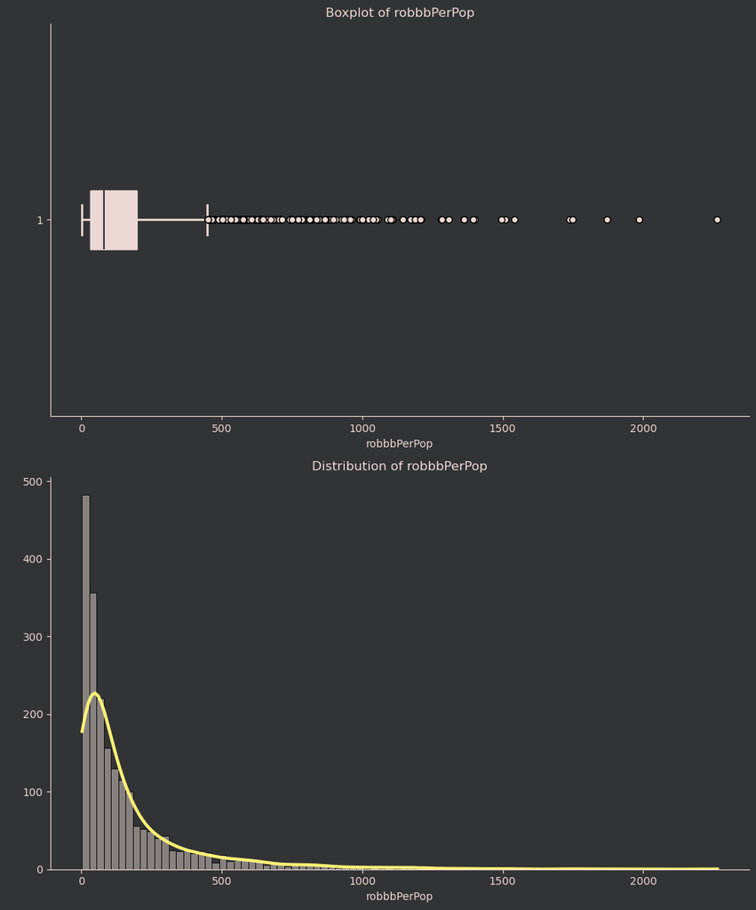

```python
boxplot(df, 'robbbPerPop')
```

```python
# removie outliers for robberies per population
df = removeOutliersIQR(df, 'robbbPerPop')
```

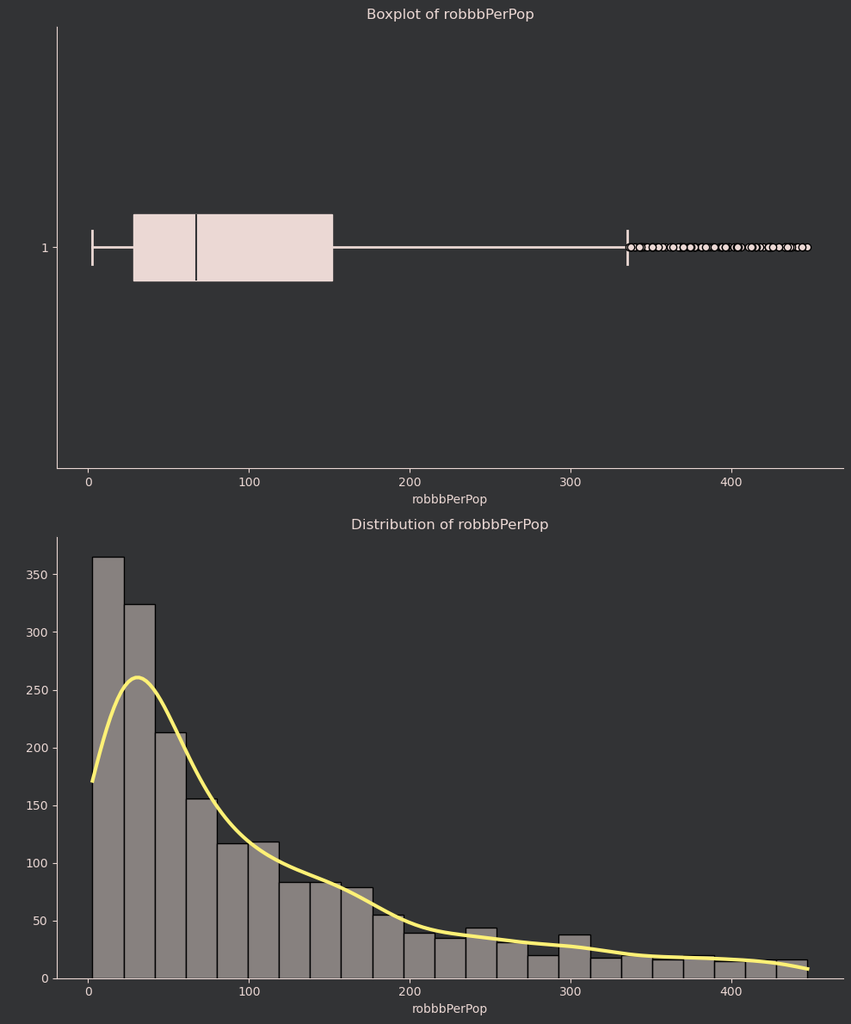

```python
boxplot(df, 'robbbPerPop')
```

```python
df[['robbbPerPop']].head()
```

|  | robbbPerPop |
| --- | --- |
| 0 | 8.20 |
| 1 | 21.26 |
| 2 | 154.95 |
| 3 | 57.86 |
| 4 | 32.04 |

```python
df['robbbPerPop'].isna().sum()
```

```
0
```

## Import Variable Classifications

```python
# load a csv with a rudimentary classification of variables to begin narrowing process
variables = pd.read_csv('datasets/variables.csv')
variables.head(3)
```

|  | Variable | Type | Description | Social Indicator | Financial Indicator | Neither | Indicator Type |
| --- | --- | --- | --- | --- | --- | --- | --- |
| 0 | state | nominal | US state (by number) | False | False | True | Neither |
| 1 | county | numeric | numeric code for county | False | False | True | Neither |
| 2 | community | numeric | numeric code for community | False | False | True | Neither |

```python
variables_df = variables[variables['Indicator Type'] == 'Financial']
variables_df.shape
```

```
(32, 7)
```

```python
# Get the list of column names from variables.csv
column_names = variables_df.iloc[:, 0].tolist()

# Filter out df columns
column_names = [col for col in column_names if col in df.columns]
filtered_df = df[column_names].copy()
filtered_df['robbbPerPop'] = df['robbbPerPop']
filtered_df.shape
```

```
(1921, 33)
```

```python
# Rename df for simplicity
df = filtered_df
df.head()
```

|  | medIncome | pctWWage | pctWFarmSelf | pctWInvInc | pctWSocSec | pctWPubAsst | pctWRetire | medFamInc | perCapInc | whitePerCap | blackPerCap | indianPerCap | AsianPerCap | OtherPerCap | HispPerCap | PctEmplManu | PctEmplProfServ | PctOccupManu | PctOccupMgmtProf | PctHousOwnOcc | OwnOccLowQuart | OwnOccMedVal | OwnOccHiQuart | RentLowQ | RentMedian | RentHighQ | MedRent | MedRentPctHousInc | MedOwnCostPctInc | … |
| --- | --- | --- | --- | --- | --- | --- | --- | --- | --- | --- | --- | --- | --- | --- | --- | --- | --- | --- | --- | --- | --- | --- | --- | --- | --- | --- | --- | --- | --- | --- |
| 0 | 75122 | 89.24 | 1.55 | 70.20 | 23.62 | 1.03 | 18.39 | 79584 | 29711 | 30233 | 13600 | 5725 | 27101 | 5115.0 | 22838 | 14.65 | 28.82 | 5.49 | 50.73 | 91.01 | 215900 | 262600 | 326900 | 685 | 1001 | 1001 | 1001 | 23.8 | 21.1 | … |
| 1 | 47917 | 78.99 | 1.11 | 64.11 | 35.50 | 2.75 | 22.85 | 55323 | 20148 | 20191 | 18137 | 0 | 20074 | 5250.0 | 12222 | 12.26 | 29.28 | 6.39 | 37.64 | 84.88 | 136300 | 164200 | 199900 | 467 | 560 | 672 | 627 | 27.6 | 20.7 | … |
| 2 | 35669 | 82.00 | 1.15 | 55.73 | 22.25 | 2.94 | 14.56 | 42112 | 16946 | 17103 | 16644 | 21606 | 15528 | 5954.0 | 8405 | 15.95 | 21.52 | 8.79 | 32.48 | 57.79 | 74700 | 90400 | 112000 | 370 | 428 | 520 | 484 | 24.1 | 21.7 | … |
| 3 | 20580 | 68.15 | 0.24 | 38.95 | 39.48 | 11.71 | 18.33 | 26501 | 10810 | 10909 | 9984 | 4941 | 3541 | 2451.0 | 4391 | 31.22 | 27.43 | 26.76 | 22.71 | 54.89 | 36400 | 49600 | 66500 | 195 | 250 | 309 | 333 | 28.7 | 20.6 | … |
| 4 | 17390 | 69.33 | 0.55 | 42.82 | 32.16 | 11.21 | 14.43 | 24018 | 8483 | 9009 | 887 | 4425 | 3352 | 3000.0 | 1328 | 6.89 | 36.54 | 10.94 | 27.80 | 53.57 | 30600 | 43200 | 59500 | 202 | 283 | 362 | 332 | 32.2 | 23.2 | … |

```python
# Evaluate columns with null entries
df.isna().sum()
```

```
medIncome                   0
pctWWage                    0
pctWFarmSelf                0
pctWInvInc                  0
pctWSocSec                  0
pctWPubAsst                 0
pctWRetire                  0
medFamInc                   0
perCapInc                   0
whitePerCap                 0
blackPerCap                 0
indianPerCap                0
AsianPerCap                 0
OtherPerCap                 1
HispPerCap                  0
PctEmplManu                 0
PctEmplProfServ             0
PctOccupManu                0
PctOccupMgmtProf            0
PctHousOwnOcc               0
OwnOccLowQuart              0
OwnOccMedVal                0
OwnOccHiQuart               0
RentLowQ                    0
RentMedian                  0
RentHighQ                   0
MedRent                     0
MedRentPctHousInc           0
MedOwnCostPctInc            0
MedOwnCostPctIncNoMtg       0
PolicOperBudg            1699
PolicBudgPerPop          1699
robbbPerPop                 0
dtype: int64
```

```python
# Eliminate the entry with a null value in 'OtherPerCap'
df = df.dropna(subset=['OtherPerCap'])

# Subset the DataFrame to include only columns without nulls
df = df[df.columns[df.notna().all()]]
```

```python
df.columns
```

```
Index(['medIncome', 'pctWWage', 'pctWFarmSelf', 'pctWInvInc', 'pctWSocSec',
       'pctWPubAsst', 'pctWRetire', 'medFamInc', 'perCapInc', 'whitePerCap',
       'blackPerCap', 'indianPerCap', 'AsianPerCap', 'OtherPerCap',
       'HispPerCap', 'PctEmplManu', 'PctEmplProfServ', 'PctOccupManu',
       'PctOccupMgmtProf', 'PctHousOwnOcc', 'OwnOccLowQuart', 'OwnOccMedVal',
       'OwnOccHiQuart', 'RentLowQ', 'RentMedian', 'RentHighQ', 'MedRent',
       'MedRentPctHousInc', 'MedOwnCostPctInc', 'MedOwnCostPctIncNoMtg',
       'robbbPerPop'],
      dtype='object')
```

[figure not shown]

# Functions

```python
def plot_quantitative_data(df, columns,
                           box_color="#EBD8D4",
                           median_color="#323335",
                           whisker_color="#EBD8D4",
                           flier_color="#EBD8D4",
                           hist_color="#ddd0ca",
                           kde_color="#fef176",
                           background_color="#323335",
                           suptitle_color="#fef176"):
    # Calculate the number of columns and rows needed for the plots
    num_columns_per_row = 4
    num_rows = (len(columns) + num_columns_per_row - 1) // num_columns_per_row  # Total rows needed for boxplots
    total_rows = num_rows * 2  # Total rows for boxplots and histograms

    # Set up the figure with the necessary number of rows and columns
    fig, ax = plt.subplots(nrows=total_rows, ncols=num_columns_per_row, figsize=(28, 5 * total_rows))
    fig.patch.set_facecolor(background_color)
    fig.suptitle('Quantitative Data Visualizations', color=suptitle_color, fontsize=22)

    # Loop through the columns and set up plots
    for i, col in enumerate(columns):
        row_index = i // num_columns_per_row  # Row index for boxplots and histograms
        col_index = i % num_columns_per_row    # Column index for boxplots and histograms

        # Boxplot
        df.boxplot(column=col, patch_artist=True,
                   boxprops=dict(facecolor=box_color, color=box_color),
                   medianprops=dict(color=median_color, linewidth=1.5),
                   whiskerprops=dict(color=whisker_color, linewidth=2),
                   capprops=dict(color=whisker_color, linewidth=2),
                   flierprops=dict(marker='o', markerfacecolor=flier_color),
                   ax=ax[row_index * 2, col_index])  # Boxplot in the first row

        ax[row_index * 2, col_index].set_title(col, color=box_color)
        ax[row_index * 2, col_index].spines['bottom'].set_color(background_color)
        ax[row_index * 2, col_index].spines['top'].set_color(background_color)
        ax[row_index * 2, col_index].spines['right'].set_color(background_color)
        ax[row_index * 2, col_index].spines['left'].set_color(box_color)
        ax[row_index * 2, col_index].set_facecolor(background_color)
        ax[row_index * 2, col_index].tick_params(axis='y', colors=box_color)
        ax[row_index * 2, col_index].grid(visible=False)
        ax[row_index * 2, col_index].set_xticklabels([])

        # Histogram
        sns.histplot(df[col], kde=True, color=hist_color, ax=ax[row_index * 2 + 1, col_index])  # Histogram in the second row

        ax[row_index * 2 + 1, col_index].set_title(col, color=box_color)
        ax[row_index * 2 + 1, col_index].spines['bottom'].set_color(background_color)
        ax[row_index * 2 + 1, col_index].spines['top'].set_color(background_color)
        ax[row_index * 2 + 1, col_index].spines['right'].set_color(background_color)
        ax[row_index * 2 + 1, col_index].spines['left'].set_color(box_color)
        ax[row_index * 2 + 1, col_index].set_facecolor(background_color)
        ax[row_index * 2 + 1, col_index].tick_params(axis='y', colors=box_color)
        ax[row_index * 2 + 1, col_index].grid(visible=False)

        # Set KDE line color and width
        if ax[row_index * 2 + 1, col_index].get_lines():
            ax[row_index * 2 + 1, col_index].get_lines()[0].set_color(kde_color)
            ax[row_index * 2 + 1, col_index].get_lines()[0].set_linewidth(3)

    # Hide any unused subplots
    for j in range(len(columns) * 2, total_rows * num_columns_per_row):
        fig.delaxes(ax.flatten()[j])

    plt.tight_layout(rect=[0, 0, 1, 0.95])
    plt.show()


def additiveOLS(df, y_name, threshold=0.001):
    X = df.drop(columns=[y_name])
    y = df[y_name]

    best_vars = []  # aggregate variables that increase r^2 the most
    remaining_vars = list(X.columns)
    r_2 = 0  # current r_2

    # Iterate until no more variables improve R^2 above the threshold
    while remaining_vars:
        best_var = None
        best_r2 = r_2

        # Test each remaining variable
        for var in remaining_vars:
            x = sm.add_constant(df[best_vars + [var]])
            model = sm.OLS(y, x).fit()
            new_r2 = model.rsquared

            # Check r^2 against previous best r_2
            if new_r2 - r_2 > best_r2 - r_2:
                best_r2 = new_r2
                best_var = var

        # if best var improves model r^2 over threshold, save the variable
        if best_r2 - r_2 > threshold:
            best_vars.append(best_var)
            remaining_vars.remove(best_var)
            r_2 = best_r2
        else:
            break

    # create and return final model
    x_final = sm.add_constant(df[best_vars])
    final_model = sm.OLS(y, x_final).fit()

    return final_model

import numpy as np
import matplotlib.pyplot as plt
import seaborn as sns

import numpy as np
import matplotlib.pyplot as plt
import seaborn as sns

import numpy as np
import matplotlib.pyplot as plt
import seaborn as sns

import numpy as np
import matplotlib.pyplot as plt
import seaborn as sns

import numpy as np
import matplotlib.pyplot as plt
import seaborn as sns

import numpy as np
import matplotlib.pyplot as plt
import seaborn as sns

import numpy as np
import matplotlib.pyplot as plt
import seaborn as sns

def plotCorrelationMatrices(df, target_variable, correlation_threshold=0, group_size=9,
                            background_color="#323335", text_color="#EBD8D4",
                            cmap=sns.diverging_palette(240, 60, l=65, center="dark", as_cmap=True)):
    """
    Plots correlation matrices for features correlated with the target variable.

    Parameters:
    - df: DataFrame containing the data.
    - target_variable: The target variable for correlation analysis.
    - correlation_threshold: Minimum correlation value to include a feature.
    - group_size: Number of features to display in each correlation matrix.
    """
    # Select only numeric columns
    numerical_df = df.select_dtypes(include=[np.number])

    # Calculate correlations with the target variable
    correlations = numerical_df.corr()[target_variable]

    # Subset features with correlation above the threshold or below its negative
    selected_features = correlations[correlations.abs() > correlation_threshold].abs().sort_values(ascending=False).index.tolist()

    # Remove the target variable from the list of features
    if target_variable in selected_features:
        selected_features.remove(target_variable)

    # Split features into groups of size `group_size`
    feature_groups = [selected_features[i:i + group_size] for i in range(0, len(selected_features), group_size)]

    # Create and display correlation matrices using Seaborn heatmap
    for idx, group in enumerate(feature_groups):
        features_to_use = [target_variable] + group
        correlation_matrix = numerical_df[features_to_use].corr()

        plt.figure(figsize=(10, 8), facecolor=background_color)

        # Create heatmap with annotations
        heatmap = sns.heatmap(correlation_matrix, annot=True, cmap=cmap,
                              linewidths=0.5, cbar_kws={"shrink": .8},
                              linecolor=background_color,
                              fmt=".2f",  # Format for the correlation coefficients
                              annot_kws={"size": 10, "color": text_color})  # Set text size and color

        plt.title(f'Correlation Matrix {idx + 1}', color=text_color)
        plt.gca().set_facecolor(background_color)
        plt.gca().spines['bottom'].set_color(text_color)
        plt.gca().spines['top'].set_color(background_color)
        plt.gca().spines['right'].set_color(background_color)
        plt.gca().spines['left'].set_color(text_color)
        plt.tick_params(axis='x', colors=text_color)
        plt.tick_params(axis='y', colors=text_color)

        # Set the color of the colorbar ticks and labels
        colorbar = heatmap.collections[0].colorbar
        colorbar.ax.tick_params(labelcolor=text_color)  # Change color of ticks

        plt.show()
```

# Quantitative Variable Distributions

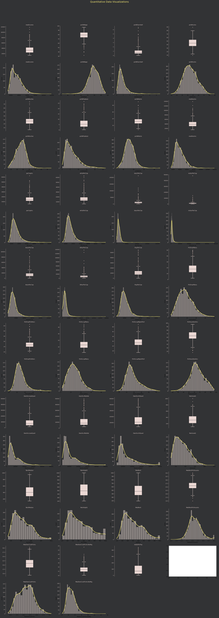

```python
plot_quantitative_data(df, df.columns)
```

```python
#Identify numeric columns
columns = df.select_dtypes(include=['number']).columns.tolist()

# Calculate correlations with 'strain_score_std'
corr = df[columns].corr()['robbbPerPop']

# Order by absolute value of correlations
corr_abs = corr.abs().sort_values(ascending=False)

# Create a list with variable name ordered by absolute correlation
correlation_list = [(col, corr[col]) for col in corr_abs.index]
correlation_list = pd.DataFrame(correlation_list, columns=['Variable', 'Correlation'])
```

```python
# Merge variables with corelation_list
variables = pd.merge(variables, correlation_list, on='Variable')

# Create a columns with the absolute value of the correlation
variables['abs_correlation'] = variables['Correlation'].abs()

# Sort variables df by absolute value of the correlation
variables = variables.sort_values(by='abs_correlation', ascending=False)
```

```python
variables[['Variable', 'Correlation', 'abs_correlation']]
```

|  | Variable | Correlation | abs_correlation |
| --- | --- | --- | --- |
| 3 | pctWInvInc | -0.421441 | 0.421441 |
| 5 | pctWPubAsst | 0.412266 | 0.412266 |
| 19 | PctHousOwnOcc | -0.389309 | 0.389309 |
| 7 | medFamInc | -0.290805 | 0.290805 |
| 0 | medIncome | -0.284730 | 0.284730 |
| 27 | MedRentPctHousInc | 0.261250 | 0.261250 |
| 18 | PctOccupMgmtProf | -0.238019 | 0.238019 |
| 17 | PctOccupManu | 0.217991 | 0.217991 |
| 8 | perCapInc | -0.213726 | 0.213726 |
| 2 | pctWFarmSelf | -0.209052 | 0.209052 |
| 1 | pctWWage | -0.199879 | 0.199879 |
| 14 | HispPerCap | -0.178575 | 0.178575 |
| 10 | blackPerCap | -0.148435 | 0.148435 |
| 12 | AsianPerCap | -0.127902 | 0.127902 |
| 26 | MedRent | -0.124173 | 0.124173 |
| 25 | RentHighQ | -0.123062 | 0.123062 |
| 24 | RentMedian | -0.122827 | 0.122827 |
| 9 | whitePerCap | -0.118769 | 0.118769 |
| 23 | RentLowQ | -0.111504 | 0.111504 |
| 20 | OwnOccLowQuart | -0.097138 | 0.097138 |
| 4 | pctWSocSec | 0.094217 | 0.094217 |
| 21 | OwnOccMedVal | -0.089016 | 0.089016 |
| 22 | OwnOccHiQuart | -0.083295 | 0.083295 |
| 28 | MedOwnCostPctInc | 0.082583 | 0.082583 |
| 13 | OtherPerCap | -0.082013 | 0.082013 |
| 16 | PctEmplProfServ | -0.079835 | 0.079835 |
| 11 | indianPerCap | -0.051921 | 0.051921 |
| 29 | MedOwnCostPctIncNoMtg | 0.031595 | 0.031595 |
| 15 | PctEmplManu | -0.012197 | 0.012197 |
| 6 | pctWRetire | -0.007567 | 0.007567 |

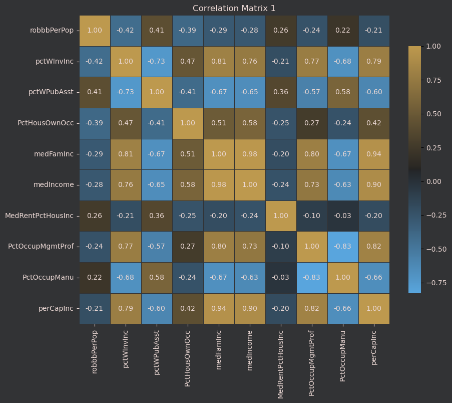

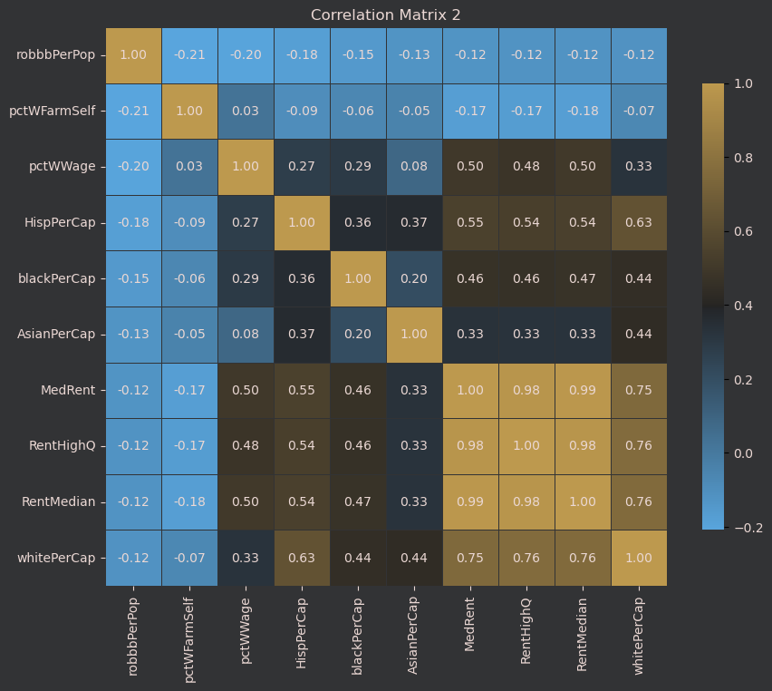

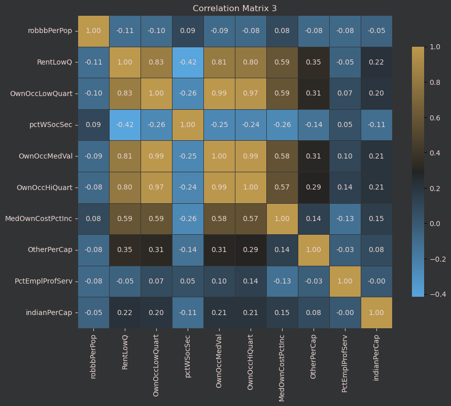

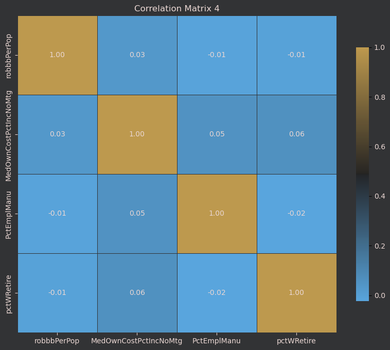

```python
plotCorrelationMatrices(df, 'robbbPerPop')
```

```python
df.shape
```

```
(1920, 31)
```

```python
model = additiveOLS(df, 'robbbPerPop', .001)
print(model.summary())
```

```
                            OLS Regression Results
==============================================================================
Dep. Variable:            robbbPerPop   R-squared:                       0.491
Model:                            OLS   Adj. R-squared:                  0.487
Method:                 Least Squares   F-statistic:                     122.3
Date:                Sun, 03 Nov 2024   Prob (F-statistic):          1.19e-265
Time:                        00:00:47   Log-Likelihood:                -10980.
No. Observations:                1920   AIC:                         2.199e+04
Df Residuals:                    1904   BIC:                         2.208e+04
Df Model:                          15
Covariance Type:            nonrobust
=========================================================================================
                            coef    std err          t      P>|t|      [0.025      0.975]
-----------------------------------------------------------------------------------------
const                   -34.5214     86.840     -0.398      0.691    -204.833     135.790
pctWInvInc               -2.7876      0.339     -8.233      0.000      -3.452      -2.124
whitePerCap               0.0385      0.002     20.846      0.000       0.035       0.042
perCapInc                -0.0346      0.002    -16.318      0.000      -0.039      -0.030
pctWFarmSelf            -25.0266      2.802     -8.932      0.000     -30.522     -19.532
PctHousOwnOcc            -1.8977      0.175    -10.865      0.000      -2.240      -1.555
MedRentPctHousInc         3.1360      0.819      3.828      0.000       1.529       4.743
pctWRetire                1.9820      0.578      3.428      0.001       0.848       3.116
RentLowQ                  0.1046      0.035      3.012      0.003       0.036       0.173
OwnOccLowQuart           -0.0005   6.77e-05     -7.243      0.000      -0.001      -0.000
pctWPubAsst               3.2628      0.754      4.330      0.000       1.785       4.741
PctEmplProfServ          -0.9347      0.343     -2.725      0.006      -1.607      -0.262
MedOwnCostPctIncNoMtg    -6.7716      1.374     -4.929      0.000      -9.466      -4.077
RentHighQ                 0.0969      0.032      2.992      0.003       0.033       0.160
pctWSocSec                2.5795      0.716      3.604      0.000       1.176       3.983
pctWWage                  2.3375      0.824      2.836      0.005       0.721       3.954
==============================================================================
Omnibus:                      264.110   Durbin-Watson:                   1.961
Prob(Omnibus):                  0.000   Jarque-Bera (JB):              472.875
Skew:                           0.881   Prob(JB):                    2.07e-103
Kurtosis:                       4.675   Cond. No.                     5.82e+06
==============================================================================

Notes:
[1] Standard Errors assume that the covariance matrix of the errors is correctly specified.
[2] The condition number is large, 5.82e+06. This might indicate that there are
strong multicollinearity or other numerical problems.
```

```python
variables_of_interest = model.model.exog_names
variables_of_interest

variables_of_interest = ['robbbPerPop'] + variables_of_interest[1:]
df = df[variables_of_interest]
df.shape
```

```
(1920, 16)
```

```python
while True:
    shape = df.shape
    for col in df.columns: df = removeOutliersIQR(df, col)
    if shape == df.shape: break
df.shape
```

```
(1151, 16)
```

```python
model = additiveOLS(df, 'robbbPerPop', .003)
print(model.summary())
```

```
                            OLS Regression Results
==============================================================================
Dep. Variable:            robbbPerPop   R-squared:                       0.427
Model:                            OLS   Adj. R-squared:                  0.422
Method:                 Least Squares   F-statistic:                     94.33
Date:                Sun, 03 Nov 2024   Prob (F-statistic):          3.05e-131
Time:                        00:00:48   Log-Likelihood:                -6042.6
No. Observations:                1151   AIC:                         1.211e+04
Df Residuals:                    1141   BIC:                         1.216e+04
Df Model:                           9
Covariance Type:            nonrobust
==================================================================================
                     coef    std err          t      P>|t|      [0.025      0.975]
----------------------------------------------------------------------------------
const             81.1719     16.734      4.851      0.000      48.338     114.005
pctWInvInc        -2.1791      0.274     -7.951      0.000      -2.717      -1.641
whitePerCap        0.0354      0.002     15.166      0.000       0.031       0.040
perCapInc         -0.0308      0.003    -11.315      0.000      -0.036      -0.025
pctWFarmSelf     -15.6586      3.527     -4.439      0.000     -22.579      -8.738
PctHousOwnOcc     -0.9822      0.143     -6.885      0.000      -1.262      -0.702
pctWRetire         2.6170      0.381      6.878      0.000       1.870       3.364
RentLowQ           0.1474      0.022      6.567      0.000       0.103       0.191
OwnOccLowQuart    -0.0003   6.02e-05     -4.959      0.000      -0.000      -0.000
pctWPubAsst        2.5088      0.739      3.394      0.001       1.058       3.959
==============================================================================
Omnibus:                       71.557   Durbin-Watson:                   2.153
Prob(Omnibus):                  0.000   Jarque-Bera (JB):               89.248
Skew:                           0.578   Prob(JB):                     4.17e-20
Kurtosis:                       3.723   Cond. No.                     1.11e+06
==============================================================================

Notes:
[1] Standard Errors assume that the covariance matrix of the errors is correctly specified.
[2] The condition number is large, 1.11e+06. This might indicate that there are
strong multicollinearity or other numerical problems.
```

```python
variables_of_interest = model.model.exog_names
variables_of_interest

variables_of_interest = ['robbbPerPop'] + variables_of_interest[1:]
df = df[variables_of_interest]
df.shape
```

```
(1151, 10)
```

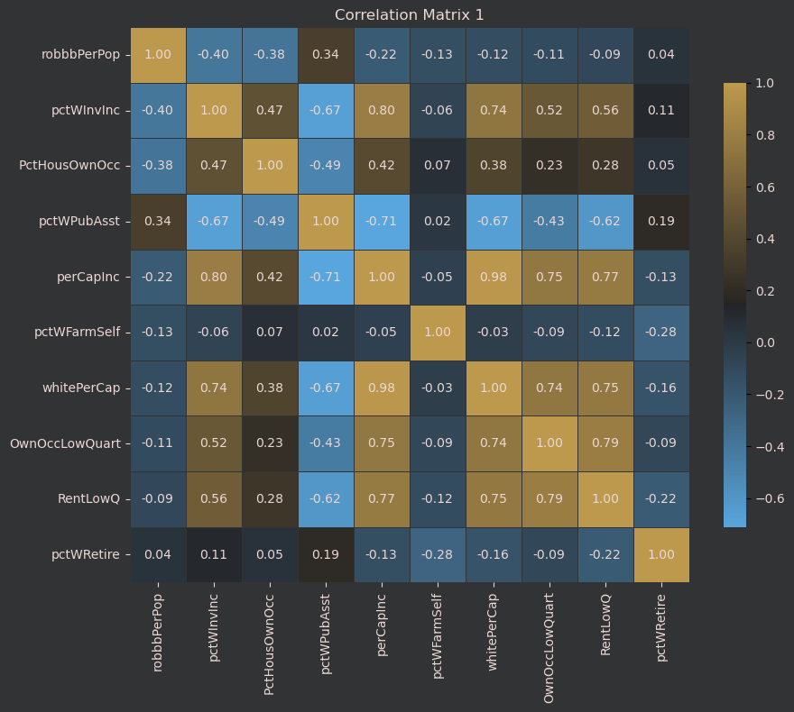

```python
plotCorrelationMatrices(df, 'robbbPerPop')
```